# K Nearest Neighbors

# 3 Visualize the Data

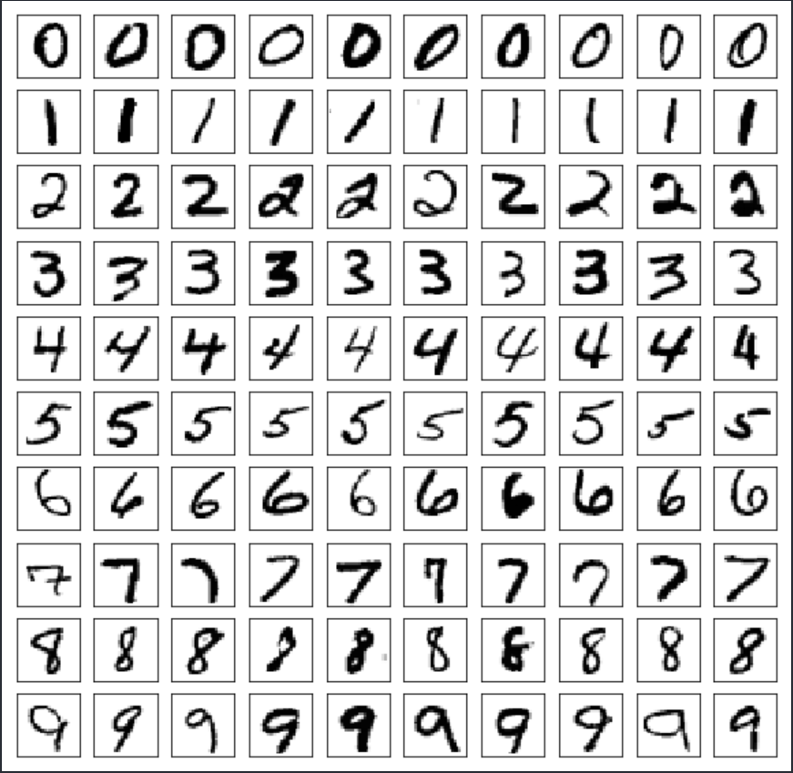

Visualizing the Data

```python
def visualize_mnist(label_array):
    fig, ax = plt.subplots(10, 10, figsize = (10,10))  # create 10x10 subplots

    for i in range(0, 10): # initiate loop
        find_digit = np.where(label_array == str(i)) # find numbers 0-9
        find_digit = mini_train_data[find_digit][0:10] # truncate data

        for j in range(0, 10): # initiate loop
            working_item = find_digit[j] # pull individual arrays
            working_item.shape = (28, 28) # reshape for viewing
            working_item = 255 - working_item # subtract itself for white background
            ax[i, j].imshow(working_item, cmap = 'gray') # plot the image
            ax[i, j].set_xticks([]) # remove axis ticks for clarity
            ax[i, j].set_yticks([]) # remove axis ticks for clarity

    return plt.show()

visualize_mnist(mini_train_labels)
```

# 4 Running an Initial Model on MNIST

```python
container = [[] for i in range(0, 2)] # create two storage containers
set_of_k = [1, 3, 5, 7, 9] # set number of k to loop through

for k in set_of_k: # begin loop
    # instantiate model
    model = KNeighborsClassifier(n_neighbors = k) # instantiate KNN
    model.fit(mini_train_data, mini_train_labels) # fit x, y

    # generate results
    predicted_y = model.predict(dev_data) # predict labels from dev data
    accuracy = accuracy_score(dev_labels, predicted_y) # compare actual to predicted

    # store data for use later
    container[0].append(k) # append K
    container[1].append(accuracy) # append accuracy

    if k == 1: # set if condition for k = 1 metric
        print(classification_report(dev_labels, predicted_y)) # compare actual to predicted
```

```
## KNeighborsClassifier(algorithm='auto', leaf_size=30, metric='minkowski',
##                      metric_params=None, n_jobs=None, n_neighbors=1, p=2,
##                      weights='uniform')
##               precision    recall  f1-score   support
##
##            0       0.95      0.95      0.95       106
##            1       0.89      0.98      0.93       118
##            2       0.90      0.79      0.84       106
##            3       0.93      0.87      0.90        97
##            4       0.91      0.85      0.88        92
##            5       0.86      0.88      0.87        88
##            6       0.92      0.92      0.92       102
##            7       0.85      0.94      0.89       102
##            8       0.83      0.77      0.80        94
##            9       0.80      0.86      0.83        95
##
##     accuracy                           0.88      1000
##    macro avg       0.88      0.88      0.88      1000
## weighted avg       0.89      0.88      0.88      1000
##
## KNeighborsClassifier(algorithm='auto', leaf_size=30, metric='minkowski',
##                      metric_params=None, n_jobs=None, n_neighbors=3, p=2,
##                      weights='uniform')
## KNeighborsClassifier(algorithm='auto', leaf_size=30, metric='minkowski',
##                      metric_params=None, n_jobs=None, n_neighbors=5, p=2,
##                      weights='uniform')
## KNeighborsClassifier(algorithm='auto', leaf_size=30, metric='minkowski',
##                      metric_params=None, n_jobs=None, n_neighbors=7, p=2,
##                      weights='uniform')
## KNeighborsClassifier(algorithm='auto', leaf_size=30, metric='minkowski',
##                      metric_params=None, n_jobs=None, n_neighbors=9, p=2,
##                      weights='uniform')
```

```python
pt = PrettyTable()
pt.field_names = ["k", "accuracy"]
for i in range(0, 5):
    pt.add_row([container[0][i], container[1][i]])
print(pt)
```

```
## +---+----------+
## | k | accuracy |
## +---+----------+
## | 1 |  0.884   |
## | 3 |  0.876   |
## | 5 |  0.882   |
## | 7 |  0.877   |
## | 9 |  0.875   |
## +---+----------+
```

There are a number of results worth interpreting here. First, we can see that the most difficult digit is `8`; owing to its low f1-score, which is a weighted average of the recall and precision score. The recall score of `0.77` makes the problem of identifying `8` most clear because recall is the ratio of `8`’s labelled correctly to those labelled correctly and those labelled incorrectly but should not have been, or: $\frac{\text{True Positive}}{\text{True Positive + False Negative}}$. Second, given our sample, we can see that as `K` increases, we gain little predictive power. However, as we will see, this is largely a function of our sample size where `n = 1000`.

# 5 MNIST: Increasing Sample Size

```python
container = [[] for i in range(0, 3)] # create 3 containers for use later
train_sizes = [100, 200, 400, 800, 1600, 3200, 6400, 12800, 25600] # set training data sizes
k = 1 # set KNN to 1
accuracies = [] # store accuracies for use later

for size in train_sizes: # start loop
    # instantiate the model and calculate the time
    start_time = time.time() # start time calcs
    model = KNeighborsClassifier(n_neighbors = k) # instantiate KNN
    train_x = train_data[0:size] # set x training data sizes via loop
    train_y = train_labels[0:size] # set y training data sizes via loop
    model = KNeighborsClassifier(n_neighbors = k) # instantiate KNN
    model.fit(train_x, train_y) # fit x, y

    # generate results and stop time
    predicted_y = model.predict(dev_data) # predict labels from dev data
    accuracy = accuracy_score(dev_labels, predicted_y) # compare actual to predicted
    end_time = time.time() # stop time
    elapsed_time = end_time - start_time # calculate the time

    # store data for use later
    container[0].append(size) # append size
    container[1].append(accuracy) # append accuracy
    container[2].append(elapsed_time) # append time
    accuracies.append(accuracy) # used later
```

```
## KNeighborsClassifier(algorithm='auto', leaf_size=30, metric='minkowski',
##                      metric_params=None, n_jobs=None, n_neighbors=1, p=2,
##                      weights='uniform')
## KNeighborsClassifier(algorithm='auto', leaf_size=30, metric='minkowski',
##                      metric_params=None, n_jobs=None, n_neighbors=1, p=2,
##                      weights='uniform')
## KNeighborsClassifier(algorithm='auto', leaf_size=30, metric='minkowski',
##                      metric_params=None, n_jobs=None, n_neighbors=1, p=2,
##                      weights='uniform')
## KNeighborsClassifier(algorithm='auto', leaf_size=30, metric='minkowski',
##                      metric_params=None, n_jobs=None, n_neighbors=1, p=2,
##                      weights='uniform')
## KNeighborsClassifier(algorithm='auto', leaf_size=30, metric='minkowski',
##                      metric_params=None, n_jobs=None, n_neighbors=1, p=2,
##                      weights='uniform')
## KNeighborsClassifier(algorithm='auto', leaf_size=30, metric='minkowski',
##                      metric_params=None, n_jobs=None, n_neighbors=1, p=2,
##                      weights='uniform')
## KNeighborsClassifier(algorithm='auto', leaf_size=30, metric='minkowski',
##                      metric_params=None, n_jobs=None, n_neighbors=1, p=2,
##                      weights='uniform')
## KNeighborsClassifier(algorithm='auto', leaf_size=30, metric='minkowski',
##                      metric_params=None, n_jobs=None, n_neighbors=1, p=2,
##                      weights='uniform')
## KNeighborsClassifier(algorithm='auto', leaf_size=30, metric='minkowski',
##                      metric_params=None, n_jobs=None, n_neighbors=1, p=2,
##                      weights='uniform')
```

```python
pt = PrettyTable()
pt.field_names = ["Training Size", "Accuracy", "Time Elapsed"]
for i in range(0, 9):
    pt.add_row([container[0][i], container[1][i], round(container[2][i], 2)])
print(pt)
```

```
## +---------------+----------+--------------+
## | Training Size | Accuracy | Time Elapsed |
## +---------------+----------+--------------+
## |      100      |  0.702   |     0.1      |
## |      200      |  0.791   |     0.18     |
## |      400      |  0.811   |     0.39     |
## |      800      |  0.866   |     0.7      |
## |      1600     |  0.905   |     1.46     |
## |      3200     |  0.927   |     3.1      |
## |      6400     |  0.939   |     6.46     |
## |     12800     |  0.952   |     13.6     |
## |     25600     |  0.963   |    29.19     |
## +---------------+----------+--------------+
```

We can see that the accuracy of our model, as shown by its accuracy score, increases as we increase the amount of data that it can learn from. Additionally, as the sample size doubles, computation time roughly doubles as well.

# 6 Confusion Matrix

```python
k = 1 # set k = 1
model = KNeighborsClassifier(n_neighbors = k) # instantiate KNN
model.fit(mini_train_data, mini_train_labels) # x, y
```

```
## KNeighborsClassifier(algorithm='auto', leaf_size=30, metric='minkowski',
##                      metric_params=None, n_jobs=None, n_neighbors=1, p=2,
##                      weights='uniform')
```

```python
predicted_y = model.predict(dev_data) # predict labels from dev data
accuracy = accuracy_score(dev_labels, predicted_y) # compare actual to predicted

# produce a confusion matrix
cm = confusion_matrix(dev_labels, predicted_y) # actual y vs predicted y
cm
```

```
## array([[101,   0,   1,   0,   0,   0,   1,   1,   2,   0],
##        [  0, 116,   1,   0,   0,   0,   0,   0,   1,   0],
##        [  1,   4,  84,   2,   2,   0,   2,   4,   6,   1],
##        [  0,   2,   0,  84,   0,   6,   0,   2,   3,   0],
##        [  0,   0,   1,   0,  78,   0,   0,   2,   0,  11],
##        [  2,   0,   0,   1,   1,  77,   5,   0,   2,   0],
##        [  1,   2,   1,   0,   1,   2,  94,   0,   1,   0],
##        [  0,   1,   1,   0,   0,   0,   0,  96,   0,   4],
##        [  1,   5,   4,   3,   1,   3,   0,   1,  72,   4],
##        [  0,   1,   0,   0,   3,   2,   0,   7,   0,  82]], dtype=int64)
```

The entry with “11” means the algorithm had the most confusion there. This means that the digits were actually “4”, but KNN predicted they were “9”. Let’s look at these examples in particular to see why it might be the case that KNN is getting confused here.

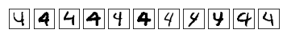

Problematic 4s

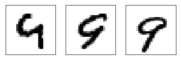

Problematic 9s

```python
# find the errors:
fours = np.where(dev_labels == '4') # return index location of all 4s
predicted = np.where(predicted_y == '9') # return index location of all 9s
confused_indx = np.intersect1d(fours, predicted) # find the index location matches in both arrays

# plot the problematic 4s
fig, ax = plt.subplots(1, 11)  # create subplots
for i in range(len(confused_indx)):
    indx = confused_indx[i]
    img_arr = dev_data[indx]
    img_arr.shape = (28, 28) # reshape for viewing
    img_arr = 255 - img_arr # subtract itself for white background
    ax[i].imshow(img_arr, cmap = 'gray') # plot the image
    ax[i].set_xticks([]) # remove axis ticks for clarity
    ax[i].set_yticks([]) # remove axis ticks for clarity

# find the errors:
nines = np.where(dev_labels == '9') # return index location of all 9s
predicted = np.where(predicted_y == '4') # return index location of all 4s
confused_indx = np.intersect1d(nines, predicted) # find the index location matches in both arrays

# plot the problematic 9s
fig, ax = plt.subplots(1, 3)  # create subplots
for i in range(len(confused_indx)):
    indx = confused_indx[i]
    img_arr = dev_data[indx]
    img_arr.shape = (28, 28) # reshape for viewing
    img_arr = 255 - img_arr # subtract itself for white background
    ax[i].imshow(img_arr, cmap = 'gray') # plot the image
    ax[i].set_xticks([]) # remove axis ticks for clarity
    ax[i].set_yticks([]) # remove axis ticks for clarity
```

The images above illustrate why that is the case nicely; they look remarkably similar in most cases. Identifying and pulling out specific errors is a great way to figure out how we might engineer solutions to these particular problems.

# 7 Feature Engineering: Image Smoothing

While our classifier does fairly well on our small training set with `k=1`, we can do much better by using an image processing technique called smoothing. This technique actually blurs the image by taking a weighted average of pixel values around each and every pixel and transforming the targeted pixel value to this new weighted average. Now, each pixel has far similar values and thus smaller distances between each other. We implement an image smoothing function below:

```python
# blur function
def blur(training_data, blur_weight):
    array = np.empty([0, 784])
    container = []
    current = np.copy(training_data) # copy required

    for image in range(len(current)):
        current_image = current[image] # pull current image
        current_image = current_image.reshape(28, 28) # reshape

        for row in range(len(current_image) - 1):
            for column in range(len(current_image) - 1): # (row, column)

                container.append(current_image[row - 1][column - 1]) # (-1, -1) pixel
                container.append(current_image[row - 1][column]) # (-1, 0) pixel
                container.append(current_image[row - 1][column + 1]) # (-1, 1) pixel
                container.append(current_image[row][column - 1]) # (0, -1) pixel
                container.append(current_image[row][column]) # (0, 0) pixel
                container.append(current_image[row][column + 1]) # (0, 1) pixel
                container.append(current_image[row + 1][column - 1]) # (1, -1) pixel
                container.append(current_image[row + 1][column]) # (1, 0) pixel
                container.append(current_image[row + 1][column + 1]) # (1, 1) pixel

                current_image[row][column] = np.mean(container)*blur_weight # add weight to current pixel
                container = [] # reset calculation container

        current_image = current_image.flatten() # return to (784, )
        array = np.append(array, [current_image], axis = 0) # add to array container

    return array
```

We then create some new data by applying our `blur` function to our training data and in turn show case its results:

```python
mini_train_blur = blur(training_data = mini_train_data, blur_weight = 0.6)
dev_train_blur = blur(training_data = dev_data, blur_weight = 0.6)
```

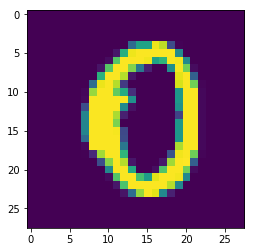

Normal 0

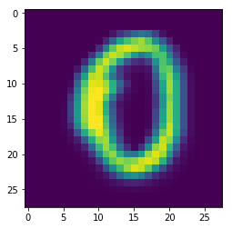

Blurred 0

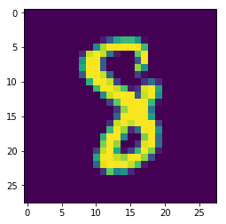

Normal 8

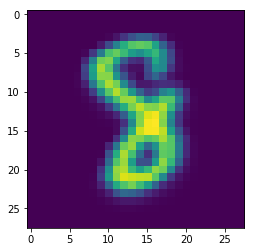

Blurred 8

```python
### show blur works
sample_img = mini_train_data[0]
sample_img = sample_img.reshape(28, 28)
plt.imshow(sample_img)
plt.show()

sample_img2 = mini_train_blur[0]
sample_img2 = sample_img2.reshape(28, 28)
plt.imshow(sample_img2)
plt.show()

###
sample_img3 = dev_data[0]
sample_img3 = sample_img3.reshape(28, 28)
plt.imshow(sample_img3)
plt.show()

sample_img4 = dev_train_blur[0]
sample_img4 = sample_img4.reshape(28, 28)
plt.imshow(sample_img4)
plt.show()
```

Next, we test to see how well our blurring function improves our predictions like so:

```python
# Model 1: No Filter
model = KNeighborsClassifier(n_neighbors = 1) # instantiate KNN
fit = model.fit(mini_train_data, mini_train_labels) # x, y

predicted_y = fit.predict(dev_data) # predict labels from dev data
accuracy = accuracy_score(dev_labels, predicted_y) # compare actual to predicted
print('the accuracy of model 1 with no filter is', accuracy)

# Model 2: Gaussian Filtered Training Data
```

```
## the accuracy of model 1 with no filter is 0.884
```

```python
model = KNeighborsClassifier(n_neighbors = 1) # instantiate KNN
fit = model.fit(mini_train_blur, mini_train_labels) # x, y

predicted_y = fit.predict(dev_data) # predict labels from dev data
accuracy = accuracy_score(dev_labels, predicted_y) # compare actual to predicted
print('the accuracy of model 2 filtered training data is', accuracy)

# Model 3: Gaussian Filtered Dev Data
```

```
## the accuracy of model 2 filtered training data is 0.864
```

```python
model = KNeighborsClassifier(n_neighbors = 1) # instantiate KNN
fit = model.fit(mini_train_data, mini_train_labels) # x, y

predicted_y = fit.predict(dev_train_blur) # predict labels from dev data
accuracy = accuracy_score(dev_labels, predicted_y) # compare actual to predicted
print('the accuracy of model 3 filtered testing data is', accuracy)

# Model 4: Gaussian Filtered Training and Dev Data
```

```
## the accuracy of model 3 filtered testing data is 0.36
```

```python
model = KNeighborsClassifier(n_neighbors = 1) # instantiate KNN
fit = model.fit(mini_train_blur, mini_train_labels) # x, y

predicted_y = fit.predict(dev_train_blur) # predict labels from dev data
accuracy = accuracy_score(dev_labels, predicted_y) # compare actual to predicted
print('the accuracy of model 4 filtered training and testing data is', accuracy)
```

```
## the accuracy of model 4 filtered training and testing data is 0.91
```

We can see that our feature engineering improves our accuracy by making it easier for KNN to classify the data.

# 8 Conclusion

This post walked through the application of the K Nearest Neighbors algorithm, demonstrating the conditions under which the algorithm excelled, did poorly, and could be improved through feature engineering.

# 9 Sources

- Matthias Feurer, Jan N. van Rijn, Arlind Kadra, Pieter Gijsbers, Neeratyoy Mallik, Sahithya Ravi, Andreas Mueller, Joaquin Vanschoren, Frank Hutter. OpenML-Python: an extensible Python API for OpenML. arXiv:1911.02490 [cs.LG], 2019
- LeCun, Yann. “The MNIST database of handwritten digits.” http://yann.lecun.com/exdb/mnist/ (1998).